# Работа с репозиториями Git и GitFlow

Лабораторная работа №4

Никифоров Захар Сергеевич

1032253520@rudn.ru

Российский университет дружбы народов

2026-03-07

# Вводная часть

## Актуальность

- Git — основной инструмент для управления версиями кода
- GitFlow — позволяет соблюдать структуру в разработке
- Знание правильной работы с репозиториями

## Объект и предмет исследования

- Объект исследования: процесс работы с репозиториями Git
- Предмет исследования: GitFlow и инструменты работы с репозиториями

## Цели и задачи

Цель: Получение навыков правильной работы с репозиториями git.

Задачи: 1. Установить необходимое ПО 2. Создать репозиторий git-extended 3. Выполнить его синхронизацию с GitHub 4. Настроить конфигурацию коммитов 5. Ознакомится с системой релизов

## Материалы и методы

- Оборудование: ПК с ОС Linux или ВМ на нем с ОС Linux
- ПО: git, gh, git-flow, node.js, pnpm
- Методы: Установка согласно руководству, работа с ветками, создание релизов.

# Порядок выполнения работы

## Установка программ

- Устанавливаем git, gh, git-flow, node.js, pnpm

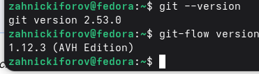

Рисунок 1: Скриншот терминала 1

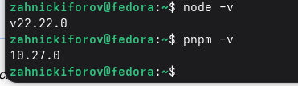

Рисунок 2: Скриншот терминала 2

## Создание Git-репозитория

- Создаем локальный репозиторий и инициализируем, получаем первый README.md, который уже закомментировали.

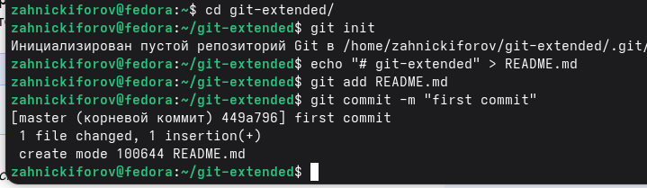

Рисунок 3: Скриншот терминала 3

## Настройка commitizen

- Используя утилиту commitizen, делаем коммит с помощью git cz

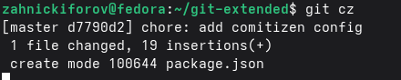

Рисунок 4: Скриншот терминала 4

## Настройка файла package.json

- Открываем package.json и редактируем его.

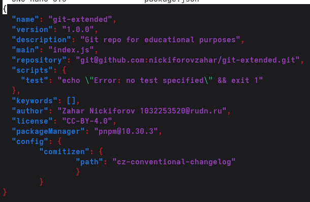

Рисунок 5: ‘package.json’

## Инициализация Git Flow и создание ветки feature.

- Инициализируем Git Flow
- Получаем базовые ветки master и develop
- Создаем ветку feature

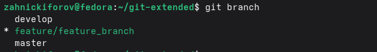

Рисунок 6: Скриншот терминала 5

## Проверка веток и создание журнала изменений

- По завершении работы с веткой feature, финишируем ее
- Проверяем ветки
- Создаем новый релиз 1.2.3 и завершаем его.

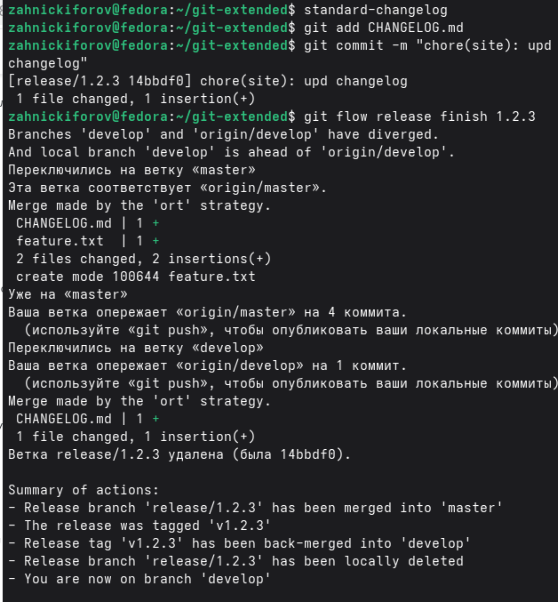

Рисунок 7: Скриншот терминала 6

# Выводы

- Были получены навыки правильной работы с репозиториями git.